# Iterate crawling and downloading files

John Little

2022-07-11

This lesson will show how to use the `rvest` package to facilitate web crawling for data. Below you will see an abridged presentation based on a longer [workshop on web crawling](https://rfun.library.duke.edu/portfolio/scraping_workshop/). The downloaded data are excel workbook files, each containing approximately 50 worksheets. Although some likely next steps could include iterating over worksheets within each workbook, I will stop short of presenting further [data wrangling techniques for concatenating readxl workflows](https://readxl.tidyverse.org/articles/readxl-workflows.html). Additionally, because the files are voluminous, at the end of this script I include a function to delete the downloaded workbook files.

That advanced worksheet wrangling can be gleaned by reading an excellent article on *readxl workflows*, particularly but not limited to the section *concatenate worksheets into one data frame*.

```r
library(tidyverse)
library(readxl)
library(fs)
library(rvest)
```

## Data

The data we will scrape is from the [US Census pulse survey](https://www.census.gov/newsroom/press-kits/2020/pulse-surveys.html). Sepcifically we will look at the data from the [pulse surveys household experience](https://www.census.gov/data/experimental-data-products/household-pulse-survey.html)

The target household data is outlined at this [summary navigation page](https://www.census.gov/programs-surveys/household-pulse-survey/data.html). [The weekly pulse surveys](https://www.census.gov/data/tables/2020/demo/hhp/hhp13.html) are linked here and each file has a different and somewhat unpredictable URL.

> We can use `rvest` to crawl the summary page and harvest the urls of target files. curl_download() to download each file into a target directory within the RStudio project on the local file system.

Here are some example files of the housing pulse survey file 2b  
- housing2b_se_week7.xlsx - housing2b_se_week13.xlsx - housing2b_week37.xlsx - housing2b_week45.xlsx

Assign some object names to useful URLs and use `read_html()` to ingest the raw HTML of the example page.

```r
my_url <- "https://www.census.gov/programs-surveys/household-pulse-survey/data.html"
base_url <- "https://www.census.gov/"

my_results <- read_html(my_url)
```

Crawl the target webpages to gather a list of URLs for files that may be download

```r
link_text <- my_results %>%
  html_nodes(".uscb-title-3") %>%
  html_text2()

link_url <- my_results %>%
  html_nodes("a.uscb-list-item") %>%
  html_attr("href")


my_crawl <- tibble(link_text, link_url, base_url) %>%
  filter(str_detect(link_text, "Household Pulse Survey:")) %>%
  unite(full_url, base_url, link_url, remove = TRUE, sep = "") %>%
  mutate(full_url = str_replace(full_url, 'gov//data', 'gov/data')) %>%
  relocate(full_url)
my_crawl
```

Use `map()` with `nest()`, `Sys.sleep()` and `libary(rvest)` to gather the target URLs that will be downloaded.

```r
crawl_results <-
  my_crawl %>%
  slice(1:6) %>%
  # select(link_text_1, full_url) %>%
  nest(parenturl = -link_text) %>%
  mutate(my_rawhtml = map(parenturl, ~ {
    Sys.sleep(2)    ## DO THIS.  Pause 2 seconds between each file.  ##
    .x %>%
      pull(full_url) %>%
      read_html() %>%
      html_nodes("a") %>%
      html_attr("href") %>%
      tibble()
    }))
```

Subset the list of downloadable files to only the `housing2b` files.

```r
download_target_urls <- crawl_results %>%
  unnest(my_rawhtml) %>%
  rename(rawhtml = 3) %>%
  filter(str_detect(rawhtml, "housing2b")) %>%
  mutate(download_xworkbook_url = str_glue("https:{rawhtml}") ) %>%
  mutate(my_filename = fs::path_file(rawhtml))
download_target_urls
```

Download the files

```r
fs::dir_create("data/xl_workbooks")

walk2(download_target_urls$download_xworkbook_url,
      str_glue("data/xl_workbooks/{download_target_urls$my_filename}"),
      curl::curl_download, mode = "wb")
```

What files did I just download?

```r
fs::dir_ls("data/xl_workbooks") %>%
  enframe()
```

## Put a bow on it.

Below shows ingesting a single excel file from among the several that were downloaded. To do more processing of the multiple workbook files see the earlier lessons. To learn more about working with the multiple worksheets withing the workbooks, read about [readxl workflows](https://readxl.tidyverse.org/articles/readxl-workflows.html)

```r
my_files <- fs::dir_ls("data/xl_workbooks", glob = "*.xlsx")

my_files <- enframe(my_files) %>%
  filter(str_detect(name, "2b_w")) %>%
  slice(1) %>%
  pull(name)
my_files

my_xl_df <- read_xlsx(my_files,
                      sheet = "NC",
                      skip = 4)

my_xl_df <- my_xl_df %>%
  janitor::clean_names()

my_xl_df %>%
  filter(select_characteristics != "Total") %>%
  mutate(sub_group = if_else(is.na(total1), select_characteristics, NA_character_)) %>%
  fill(sub_group, .direction = "down") %>%
  relocate(sub_group) %>%
  filter(sub_group == "Education")
```

```r
# read_excel(my_files, sheet = "NC", range = "A8:J132")
# read_excel(my_files, sheet = "SC", range = "A8:J132")

my_files <- fs::dir_ls("data/xl_workbooks", glob = "*.xlsx")
path <- my_files[8]

my_files[8] %>%
  excel_sheets() %>%
  set_names() %>%
  grep("[NS]C", ., value = TRUE) %>%
  map_df(., ~ read_excel(path, sheet = .x), .id = "sheet")

ranges <- list("A8:J132", cell_rows(8:132))
my_files %>%
  excel_sheets() %>%
  set_names() %>%
  grep("[NS]C", ., value = TRUE) %>%
  map2_df(., ranges, ~ read_excel(path, sheet = .x,
                                  range = "A8:J132",
                                  col_names = FALSE), .id = "sheet")
my_files %>%
  excel_sheets() %>%
  set_names() %>%
  grep("[NS]C", ., value = TRUE) %>%
  map_df(., ~ read_excel(path, sheet = .x,
                         range = "A8:J132",
                         col_names = FALSE), .id = "sheet")
```

```r
my_files <- fs::dir_ls("data/xl_workbooks", glob = "*.xlsx")
path <- my_files[8]

my_files[8] %>%
  excel_sheets() %>%
  set_names() %>%
  grep("[NS]C", ., value = TRUE)  %>%
  map_df(., ~ read_excel(my_files[8], sheet = .x), .id = "sheet")


foo_files <- my_files %>%
  enframe() %>%
  filter(str_detect(value, "2b_w")) %>%
  pull(name)

grep_sheets <- function(my_vec) {
  my_vec %>%
    excel_sheets() %>%
    set_names() %>%
    grep("[NS]C", ., value = TRUE) %>%
    list()
}

foo_files
xl_to_read <- map(foo_files,  grep_sheets) %>% unlist()
xl_to_read

xl_to_read <- map(foo_files,  grep_sheets)
xl_to_read %>% as.character()

ranges <- list("A5:F15", cell_rows(5:15))



map2_df(foo_files, xl_to_read, ~ read_excel(.x, sheet = .y), id = "sheet")
map2_df(foo_files, , ~ read_excel(.x, sheet = .y), id = "sheet")

map2_df(xl_to_read %>% as.character(), foo_files, ~read_excel(.y, sheet = .x), id = "sheet")

foo_files %>%
    excel_sheets() %>%
    set_names() %>%
    grep("[NS]C", ., value = TRUE) %>%
    list()

my_files %>%
  enframe() %>%
  filter(str_detect(name, "2b_w")) %>%
  nest(-value) %>%
  # slice_head(n = 1) %>% unnest()
  mutate(my_sheet = map(data, pull)) %>% unnest(my_sheet)
  map_chr(my_sheet2 = map_chr(my_sheet, excel_sheets))

my_files %>%
  enframe() %>%
  filter(str_detect(name, "2b_w")) %>%
  mutate(my_esh = map(name, excel_sheets))  %>%
  mutate(my_setnames = map(my_esh, set_names)) %>%
  mutate(my_grep = map(my_setnames, ~ grep("[NS]C", .x, value = TRUE))) %>%
  mutate(me_xldf = map(my_grep, ~ read_excel(name, sheet = .x), id = "sheet"))
  # pull(my_grep)

my_files

my_files %>%
  enframe() %>%
  pull(name) %>%
  excel_sheets() %>%
  set_names()

my_files %>%
  grep("2b_w", ., value = TRUE) %>%
  map_df(read_xlsx)

nc_df <- tibble( me_df = my_files %>%
  grep("2b_w", ., value = TRUE) %>%
  map_df(~ read_xlsx, sheet = "NC"), id = "sheet") %>%
  unnest(me_df)
nc_df

sc_df <- tibble( me_df = my_files %>%
  grep("2b_w", ., value = TRUE) %>%
  map_df(read_xlsx, sheet = "SC")) %>%
  unnest(me_df)
sc_df

my_files %>%
  enframe() %>%
  filter(str_detect(name, "2b_w")) %>%


my_files[8] %>%
  excel_sheets() %>%
  set_names() %>%
  grep("[NS]C", ., value = TRUE) -> flump
```

```r
my_files <- fs::dir_ls("data/xl_workbooks", glob = "*.xlsx") %>%
  grep("2b_w", ., value = TRUE)

my_files[3] %>%
  excel_sheets() %>%
  set_names() %>%
  grep("[NS]C", ., value = TRUE)  %>%
  map_df(., ~ read_excel(my_files[3], sheet = .x,
                         range = "A8:J132",
                         col_names = FALSE), .id = "sheet") %>%
  mutate(file = my_files[3]) %>%
  relocate(file)

my_df_build <- my_files[1] %>%
  excel_sheets() %>%
  set_names() %>%
  grep("[NS]C", ., value = TRUE)  %>%
  map_df(., ~ read_excel(my_files[1], sheet = .x,
                         range = "A8:J132",
                         col_names = FALSE), .id = "sheet") %>%
    mutate(file = my_files[1]) %>%
    relocate(file)
my_df_build
my_df_build <- tibble()
# i <-  1
```

### This works!!!

```r
# get filenames and limit to relevant files 'housing2b_week999'
my_files <- fs::dir_ls("data/xl_workbooks", glob = "*.xlsx") %>%
  grep("2b_w", ., value = TRUE)

# get and repair filenames
getcolnamesa <- read_excel(my_files[1], range = "A5:J5")
getcolnamesb <- read_excel(my_files[1], range = "A6:J6")
getcolnames <-
  c(names(getcolnamesa[1:2]),
    names(getcolnamesb[3:8]),
    names(getcolnamesa[9:10]))
# getcolnames
getcolnames[1] <- "select_characteristics"
getcolnames[2] <- "total"

# for Loop to build big data frame
my_df_build <- tibble()
for(i in 1:length(my_files)) {
  my_iterate_df <-   my_files[i] %>%
    excel_sheets() %>%
    set_names() %>%
    grep("[NS]C", ., value = TRUE)  %>%
    map_df(., ~ read_excel(my_files[i], sheet = .x,
                           range = "A8:J132",
                           col_names = FALSE), .id = "sheet") %>%
    mutate(file = my_files[i]) %>%
    relocate(file, .before = sheet)

  my_df_build <- bind_rows(my_df_build, my_iterate_df)
}

# Assign proper filenames
names(my_df_build)[3:12] <- getcolnames
# names(my_df_build)
```

```r
ls()
```

```
[1] "getcolnames"   "getcolnamesa"  "getcolnamesb"  "i"
[5] "my_df_build"   "my_files"      "my_iterate_df"
```

```r
wrangle_df <- . %>%
  filter(select_characteristics != "Total") %>%
  mutate(sub_group = if_else(is.na(total),
                             select_characteristics,
                             NA_character_)) %>%
  fill(sub_group, .direction = "down") %>%
  relocate(sub_group) %>%
  drop_na(total) %>%
  filter(sub_group == "Education") %>%
  mutate(across(total:last_col(), as.numeric))

# wrangle_df <- function(my_df, ...) {
#   {{my_df}} %>%
#     filter(select_characteristics != "Total") %>%
#     mutate(sub_group = if_else(is.na(total),
#                                select_characteristics,
#                                NA_character_)) %>%
#     fill(sub_group, .direction = "down") %>%
#     relocate(sub_group) %>%
#     drop_na(total) %>%
#     filter(sub_group == "Education") %>%
#     mutate(across(total:last_col(), as.numeric))
# }

prep_barplot_df <- function(my_df, ...) {
  {{my_df}} %>%
  pivot_longer(total:last_col(), names_to = "my_category") %>%
  group_by(sub_group, file, sheet, select_characteristics, my_category)  %>%
  summarise(totals = sum(value, na.rm = TRUE)) %>%
  ungroup()
  }

make_barblot <- function(my_df, xaxis, yaxis, my_facet, ...) {
  ggplot(data = {{my_df}}, aes({{xaxis}}, {{yaxis}})) +
    geom_col() +
    coord_flip() +
    facet_wrap(vars({{my_facet}}))
  }
```

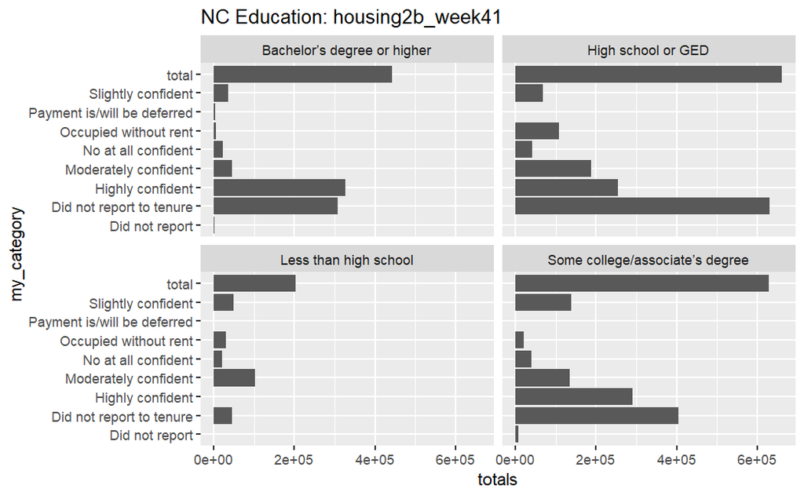

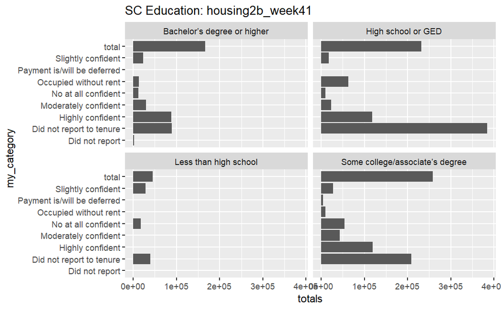

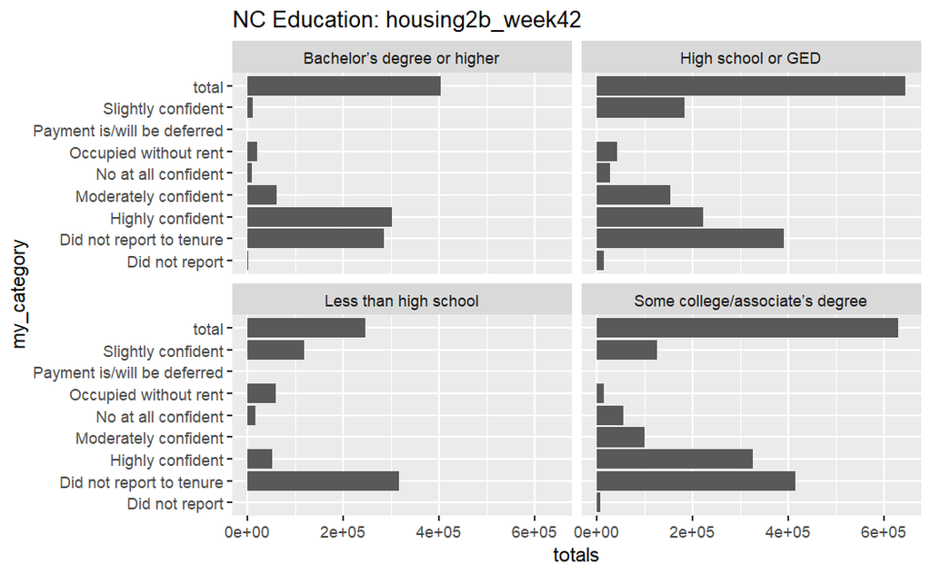

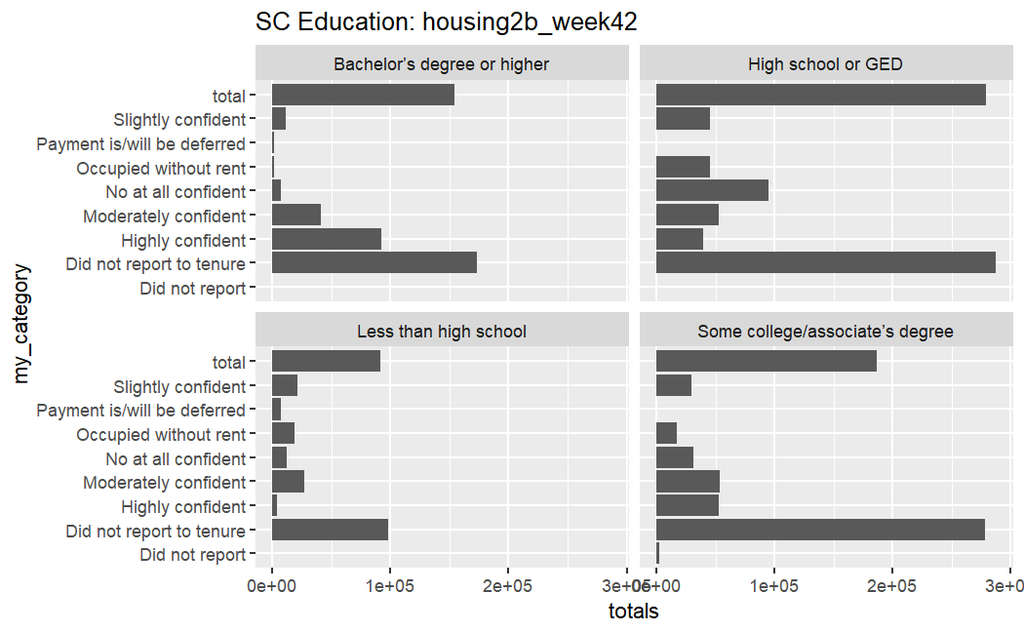

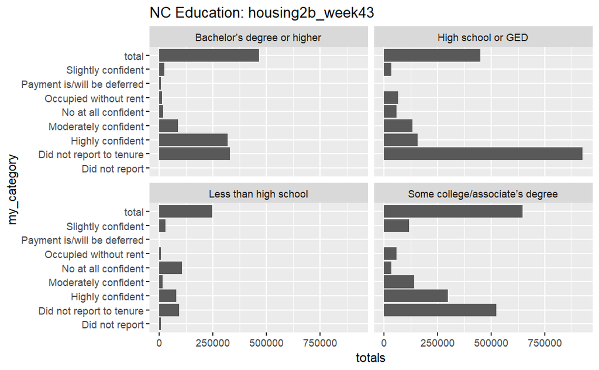

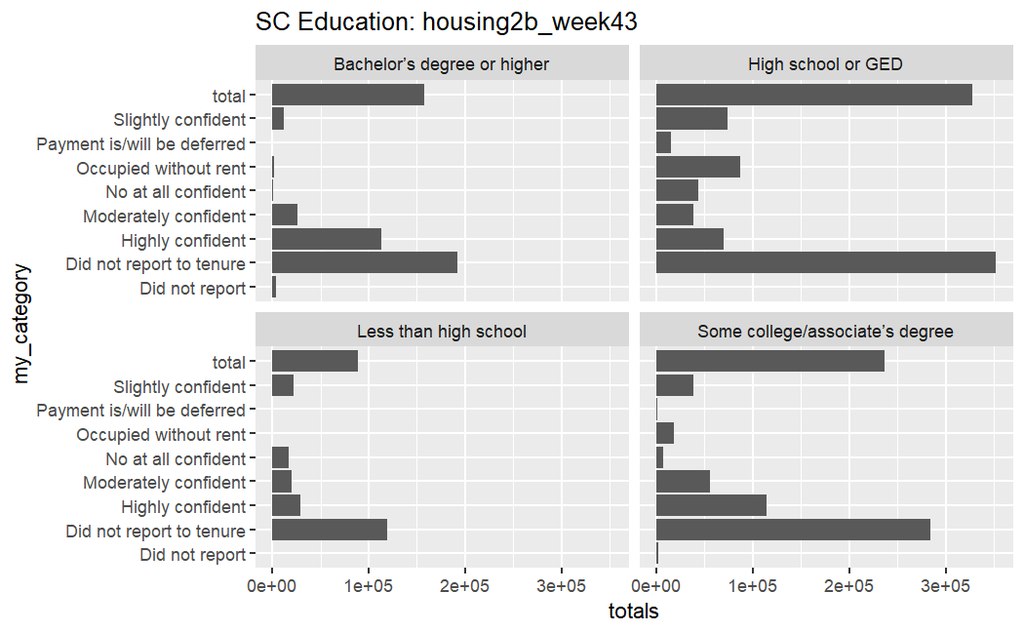

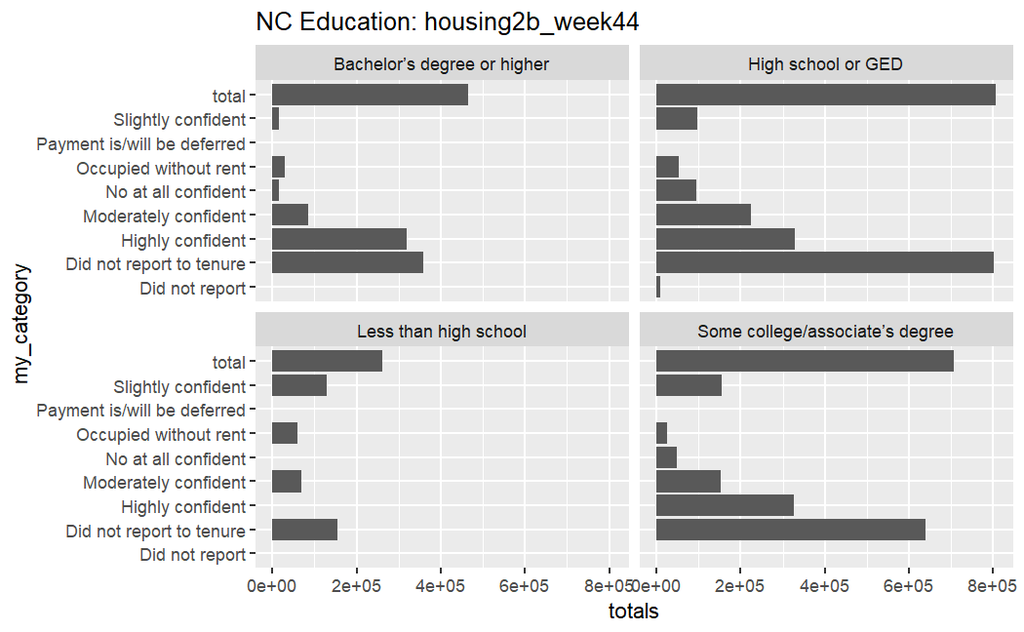

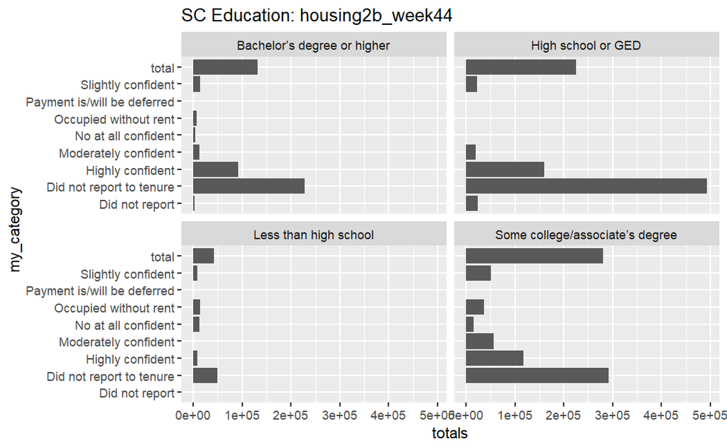

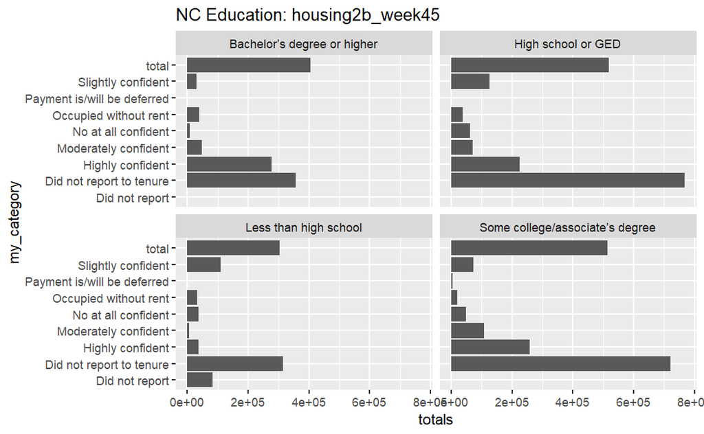

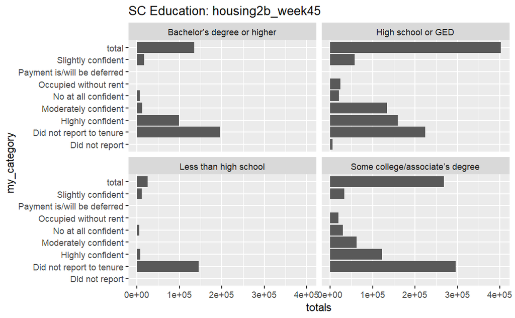

```r
my_df_build %>%
  wrangle_df() %>%
  pivot_longer(total:last_col(), names_to = "my_category") %>%
  group_by(sub_group, file, sheet, select_characteristics, my_category)  %>%
  summarise(totals = sum(value, na.rm = TRUE)) %>%
  # ungroup() %>%
  nest(data = -c(sub_group, file, sheet)) %>%
  mutate(myplot = map(data, make_barblot, my_category, totals, select_characteristics)) %>%
  mutate(plot_title = fs::path_ext_remove(fs::path_file(file))) %>%
  mutate(myplot = map(myplot, ~ .x + ggtitle(str_glue("{sheet} {sub_group}: {plot_title}")))) %>%
  pull(myplot)
```

```r
my_df_build %>%
  filter(`...3` != "Total") %>%
  mutate(sub_group = if_else(is.na(`...4`), `...3`, NA_character_)) %>%
  fill(sub_group, .direction = "down") %>%
  relocate(sub_group) %>%
  drop_na(`...4`) %>%
  filter(sub_group == "Education") %>%
  nest(-c(1:3))

my_df_build %>%
  filter(`...3` != "Total") %>%
  mutate(sub_group = if_else(is.na(`...4`), `...3`, NA_character_)) %>%
  fill(sub_group, .direction = "down") %>%
  relocate(sub_group) %>%
  drop_na(`...4`) %>%
  filter(sub_group == "Education") %>%
  nest(-c(1:3)) %>%
  head(1) %>%
  unnest() %>%
  pivot_longer(5:last_col(), names_to = "my_category") %>%
  filter(value != "-") %>%
  mutate(value = as.numeric(value)) %>%
  group_by(sub_group, file, sheet, `...3`, my_category)  %>%
  summarise(totals = sum(value, na.rm = TRUE)) %>%
  ggplot(aes(my_category, totals)) +
  geom_col() +
  coord_flip() +
  facet_wrap(~ `...3`)
```

```r
my_files %>%
  excel_sheets() %>%
  set_names() %>%
  grep("[NS]C", ., value = TRUE) %>%
  map_df(., ~ read_excel(path, sheet = .x,
                         range = "A8:J132",
                         col_names = FALSE,
                         col_types = c("text", rep("numeric", 9))),
         .id = "sheet") %>%
  filter(`...1` != "Total") %>%
  mutate(sub_group = if_else(is.na(`...2`), `...1`, NA_character_)) %>%
  fill(sub_group, .direction = "down") %>%
  relocate(sub_group) %>%
  drop_na(4) %>%
  filter(sub_group == "Education") %>%
  pivot_longer(4:last_col(), names_to = "my_category") %>%
  group_by(sub_group, sheet, 3, my_category) %>%
  summarise(totals = sum(value, na.rm = TRUE)) %>%
  ggplot(aes(my_category, totals)) +
  geom_col() +
  coord_flip() +
  facet_wrap(~ sheet)
```

## Delete the downloaded files

```r
fs::dir_delete("data/xl_workbooks")
```